# Data Analysis Project code

UN data clustering analysis

# Libraries

Load necessary libraries.

```r
library(pdftools)
library(tidyverse)

library(tm)

library(ggplot2)
library(lsa)

library(wordcloud)

library(magrittr)
library(dplyr)
library(ggpubr)

library(proxy)

library(cluster)
library(dendextend)

library(tidytext)
library(topicmodels)
```

# Create a vector

Create a vector data structure in R of the UN PDF file names using the `list.files` function.

```r
all_files <- list.files(pattern = "pdf$", ignore.case=TRUE)
all_files

typeof(all_files)
```

In the `pdftools` library, the function pdf_text is used to extract text. Using the `lapply` function, the pdf_text function can be applied to each element in the “all_files” vector to then create an object called “UN_files”.

```r
UN_files <- lapply(all_files, pdf_text)
```

```r
length(UN_files)
```

```
[1] 30
```

```r
lapply(UN_files, length)
```

# Text mining

Load the `tm package` and then create a corpus, which is essentially a database for the UN texts.

```r
UN_corpus <- Corpus(URISource(all_files),
               readerControl = list(reader = readPDF))
```

## Term-document matrix

Having created a corpus called `UN_corpus`, a term-document matrix (TDM) can be generated, which stores counts of terms for each document. First, the punctuation marks have to be removed.

```r
UN_corpus <- tm_map(UN_corpus, removePunctuation, ucp = TRUE)
```

```r
UN_corpus.tdm <- TermDocumentMatrix(UN_corpus,
                                   control =
                                     list(stopwords = TRUE,
                                          tolower = TRUE,
                                          stemming = TRUE,
                                          removeNumbers = TRUE,
                                          bounds = list(global = c(3, Inf))))
```

Inspect the UN_corpus term-document matrix:

```r
inspect(UN_corpus.tdm[1:10,])
```

### Summary statistics

There are a few functions for summary statistics in the `tm package`. For instance, the `findFreqTerms` function can find frequently occurring terms. Words that occur at least 100 times are shown here:

```r
findFreqTerms(UN_corpus.tdm, lowfreq = 100, highfreq = Inf)
```

The counts of these words can be shown in each of the UN report PDF documents:

```r
frequent_terms <- findFreqTerms(UN_corpus.tdm, lowfreq = 100, highfreq = Inf)
as.matrix(UN_corpus.tdm[frequent_terms,])
```

The total counts for the most frequent words can be saved into a matrix. The sum function is subsequently applied across the rows:

```r
frequent_terms.tdm <- as.matrix(UN_corpus.tdm[frequent_terms,])
sort(apply(frequent_terms.tdm, 1, sum), decreasing = TRUE)
```

# Document-term matrix

NB: In a document-term matrix, rows represent documents in the collection and columns represent terms, whereas the term-document matrix is the transpose of DTM. Create document-term matrix:

```r
UN_corpus <- tm_map(UN_corpus, removePunctuation, ucp = TRUE)

dtm = DocumentTermMatrix(UN_corpus,
                         control = list(
                                        stopwords = TRUE,
                                        tolower = TRUE,
                                        removeNumbers = TRUE,
                                        stemming = TRUE,
                                        bounds = list(global = c(3, Inf))))

dtm <- dtm[, names(head(sort(colSums(as.matrix(dtm))), 400))]
dtm <- dtm[, names(sort(colSums(as.matrix(dtm))))]

inspect(dtm)
```

## TF-IDF

Term frequency-inverse document frequency (TF-IDF):

```r
UN_dtm <- weightTfIdf(dtm, normalize = TRUE)
dtm.matrix = as.matrix(UN_dtm)

inspect(UN_dtm)
```

# Calculating Distance

The clustering algorithm uses distances to cluster documents.

## Euclidean distance

Use the `dist` function (for matrix distance/ similarity computation) to calculate the Euclidean distance between the documents.

```r
UN_dtm <- as.matrix(UN_dtm)
distMatrix_Euclidean <- dist(UN_dtm, method="euclidean")
print(distMatrix_Euclidean)

# NB: For continuous numerical values, use Euclidean distance
```

## Cosine distance

```r
# For cosine similarity matrix
cosine_matrix <- as.matrix(dtm)
UN_cosine_sim <- cosine_matrix / sqrt(rowSums(cosine_matrix * cosine_matrix))
UN_cosine_sim <- UN_cosine_sim %*% t(UN_cosine_sim)

# Convert to distance matrix
UN_cosine_sim <- as.dist(UN_cosine_sim)
```

**NB**: A cosine dissimilarity matrix can be generated to determine the extent to which the UN documents are different. This will not, however, be used for further analysis.

```r
#Generate cosine dissimilarity matrix (distance matrix)
UN_cosine_dissimilarity <- as.dist(1 - UN_cosine_sim)
```

### Heat map

The visualisation below presents a heat map of the cosine similarity of the UN corpus.

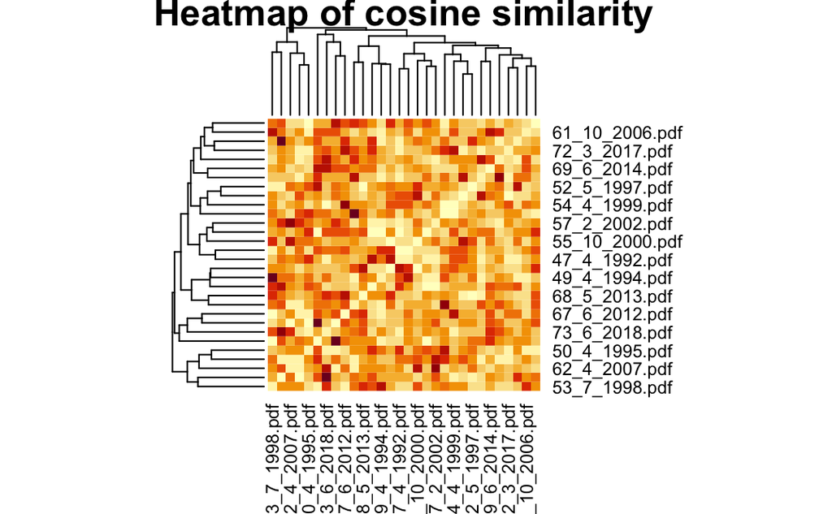

```r
UN_cosine_sim_heatmap <- as.matrix(UN_cosine_sim)

heatmap(UN_cosine_sim_heatmap,
        main="Heatmap of cosine similarity")
```

# Clustering

The tree can be cut into clusters. These can either be determined arbitrarily or based on one of three methods (the Elbow method, Average silhouette method or Gap statistic method).

```r
library(dendextend)
hclust_average <- hclust(UN_cosine_sim, method = "ward")
```

```
The "ward" method has been renamed to "ward.D"; note new "ward.D2"
```

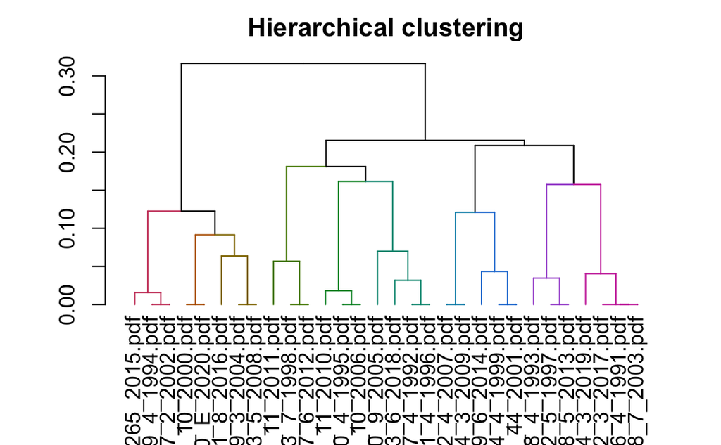

```r
average_dend_obj <- as.dendrogram(hclust_average)
average_column_dend <- color_branches(average_dend_obj, k = 10, h = 10)
plot(average_column_dend,
     main="Hierarchical clustering")
```

## Hierarchical clustering: “average” linkage method

In hierarchical agglomerative cluster analysis (HAC, for short), there are numerous linkage methods that can be used to generate the different clusters. Another option would be `average`, as shown below.

The following dendrogram is produced, whereby each data point eventually merges into a single cluster with the height (or distance) indicated on the y-axis. This uses the `dendextend` library.

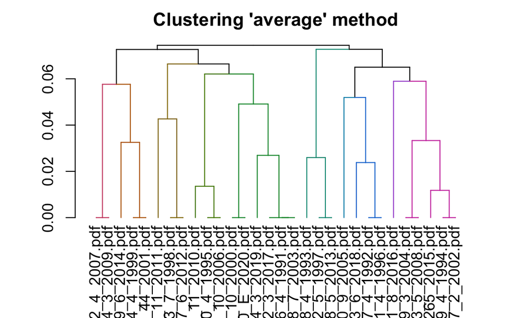

```r
library(dendextend)
hclust_average <- hclust(UN_cosine_sim, method = "average")

average_dend_obj <- as.dendrogram(hclust_average)
average_column_dend <- color_branches(average_dend_obj, k = 10, h = 10)
plot(average_column_dend,
     main="Clustering 'average' method" )
```

## “Centroid” linkage method

In hierarchical agglomerative cluster analysis (HAC, for short), there are numerous linkage methods that can be used to generate the different clusters. Another option would be `centroid`, as shown below.

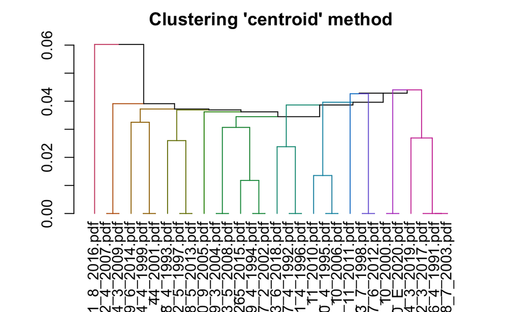

```r
hclust_centroid <- hclust(UN_cosine_sim, method = "centroid")
centroid_dend_obj <- as.dendrogram(hclust_centroid)
centroid_column_dend <- color_branches(centroid_dend_obj, k = 12, h = 12)
plot(centroid_column_dend,
     main="Clustering 'centroid' method")
```

## “Mcquitty” linkage method

In hierarchical agglomerative cluster analysis (HAC, for short), there are numerous linkage methods that can be used to generate the different clusters. Another option would be `mcquitty`, as shown below.

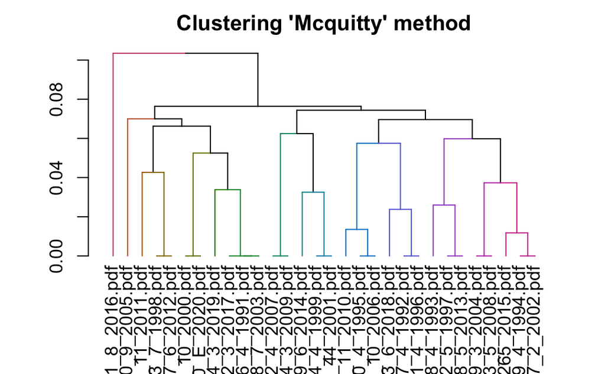

```r
hclust_mcquitty <- hclust(UN_cosine_sim, method = "mcquitty")
mcquitty_dend_obj <- as.dendrogram(hclust_mcquitty)
mcquitty_column_dend <- color_branches(mcquitty_dend_obj, k = 15, h = 15)
plot(mcquitty_column_dend,
     main="Clustering 'Mcquitty' method")
```

## Divisive hierarchical clustering

Divisive hierarchical clustering is the inverse of hierarchical clustering since it starts off with one cluster containing the whole dataset. Subsequently, the observation with the highest average dissimilarity (in other words, the one farthest from the cluster according to a specific metric) is reassigned to its own cluster. It uses the `cluster` package and the `diana` (DIvisive ANAlysis) function.

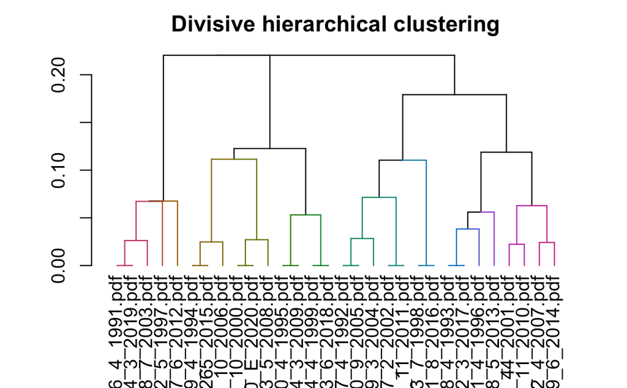

```r
divisive_hclust <- diana(UN_cosine_sim, stand=TRUE)

divisive_dend_obj <- as.dendrogram(divisive_hclust)
divisive_column_dend <- color_branches(divisive_dend_obj, k = 15, h = 15)
plot(divisive_column_dend,
     main="Divisive hierarchical clustering")
```

# LDA: Latent Dirichlet allocation

Latent Dirichlet allocation is a topic modelling algorithm that is based on two guiding principles: + Every document is a mixture of topics; + Every topic is a mixture of words. The package `topicmodels` is used for the LDA method.

```r
lda_text <- LDA(dtm, k=2, method = "VEM", control = NULL)
lda_text
```

```
A LDA_VEM topic model with 2 topics.
```

The 10 most common words in each group topic can be visualising using the `tidytext` Text Mining package. Thus, the “beta” method is used in order to extract the per-topic-per-word probabilities.

```r
lda_topics <- tidy(lda_text, matrix = "beta")
lda_topics
```

The above tibble data frame can then be plotted.

```r
lda_top_terms <- lda_topics %>%
  group_by(topic) %>%
  slice_max(beta, n=10) %>%
  ungroup() %>%
  arrange(topic, -beta)

lda_top_terms %>%
  mutate(term = reorder(term, beta)) %>%
  ggplot(aes(term, beta, fill = factor(topic))) +
  labs(title="Top 10 most common terms per topic",
        x ="Term", y = "LDA (beta)") +
  theme(plot.title=element_text(color="coral4", size=16, face="bold.italic"),
        axis.title.x = element_text(color="coral4", size=14, face="bold"),
        axis.title.y = element_text(color="coral4", size=14, face="bold")) +
  scale_fill_manual(values = c("lightgoldenrod4", "salmon")) +
  geom_col(show.legend = TRUE) +
  facet_wrap(~topic, scales="free_x") +
  coord_flip()
```

[output not shown]

## LDA Log ratio

The greatest difference in beta between the two topics can likewise be considered with the help of a log ratio. This analysis relies on the `tidyr` package.

```r
lda_logRatio <- lda_topics %>%
  mutate(topic = paste0("topic", topic)) %>%
  spread(topic, beta) %>%
  filter(topic1 > 0.001 | topic2 > 0.001) %>% # filter for common words that have a beta greater than 1/1000 in at least 1 topic
  mutate(log_ratio = log2(topic2 / topic1))

lda_logRatio
```

The above tibble data frame can be plotted as follows:

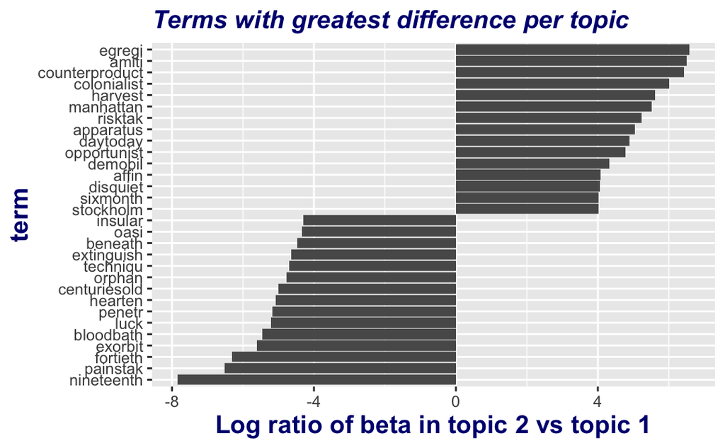

```r
lda_logRatio %>%
  group_by(direction = log_ratio > 0) %>%
  top_n(15, abs(log_ratio)) %>%
  ungroup() %>%
  mutate(term = reorder(term, log_ratio)) %>%
  ggplot(aes(term, log_ratio)) +
  geom_col() +
  labs(title = "Terms with greatest difference per topic",
       y= "Log ratio of beta in topic 2 vs topic 1") +
  theme(plot.title=element_text(color="navy", size=14, face="bold.italic"),
        axis.title.x = element_text(color="navy", size=14, face="bold"),
        axis.title.y = element_text(color="navy", size=14, face="bold")) +
  scale_fill_manual(values = c("slateblue4", "gold2")) +
  coord_flip()
```

## LDA Document-topic probabilities

Latent Dirichlet Allocation can also model each UN General Assembly report (from 1991 to 2020) as a mixture of topics. In this case, the “gamma” method is used in order to extract the per-document-per-topic probabilities, in other words, it indicates the proportion of the document that consists of words from the assigned topic

```r
lda_documents <- tidy(lda_text, matrix ="gamma")
lda_documents
```

```r
top_n(lda_documents, 10)
```

A boxplot can illustrate how well the unsupervised learning algorithm distinguishes between the different topics for each of the UNGA reports.

```r
lda_documents %>%
  mutate(title=reorder(document, gamma*topic)) %>%
  ggplot(aes(factor(topic), gamma)) +
  geom_boxplot(fill="gold", color="deeppink1") +
  facet_wrap(~document)
```

[output not shown]